Note

Go to the end to download the full example code or to run this example in your browser via JupyterLite or Binder.

# Blind source separation using FastICA

An example of estimating sources from noisy data.

Independent component analysis (ICA) is used to estimate sources given noisy measurements. Imagine 3 instruments playing simultaneously and 3 microphones recording the mixed signals. ICA is used to recover the sources ie. what is played by each instrument. Importantly, PCA fails at recovering our `instruments` since the related signals reflect non-Gaussian processes.

```
# Authors: The scikit-learn developers
# SPDX-License-Identifier: BSD-3-Clause
```

## Generate sample data

```
import numpy as np
from scipy import signal

np.random.seed(0)
n_samples = 2000
time = np.linspace(0, 8, n_samples)

s1 = np.sin(2 * time)  # Signal 1 : sinusoidal signal
s2 = np.sign(np.sin(3 * time))  # Signal 2 : square signal
s3 = signal.sawtooth(2 * np.pi * time)  # Signal 3: saw tooth signal

S = np.c_[s1, s2, s3]
S += 0.2 * np.random.normal(size=S.shape)  # Add noise

S /= S.std(axis=0)  # Standardize data
# Mix data
A = np.array([[1, 1, 1], [0.5, 2, 1.0], [1.5, 1.0, 2.0]])  # Mixing matrix
X = np.dot(S, A.T)  # Generate observations
```

## Fit ICA and PCA models

```
from sklearn.decomposition import PCA, FastICA

# Compute ICA
ica = FastICA(n_components=3, whiten="arbitrary-variance")
S_ = ica.fit_transform(X)  # Reconstruct signals
A_ = ica.mixing_  # Get estimated mixing matrix

# We can `prove` that the ICA model applies by reverting the unmixing.
assert np.allclose(X, np.dot(S_, A_.T) + ica.mean_)

# For comparison, compute PCA
pca = PCA(n_components=3)
H = pca.fit_transform(X)  # Reconstruct signals based on orthogonal components
```

## Plot results

```
import matplotlib.pyplot as plt

plt.figure()

models = [X, S, S_, H]
names = [
    "Observations (mixed signal)",
    "True Sources",
    "ICA recovered signals",
    "PCA recovered signals",
]
colors = ["red", "steelblue", "orange"]

for ii, (model, name) in enumerate(zip(models, names), 1):
    plt.subplot(4, 1, ii)
    plt.title(name)
    for sig, color in zip(model.T, colors):
        plt.plot(sig, color=color)

plt.tight_layout()
plt.show()
```

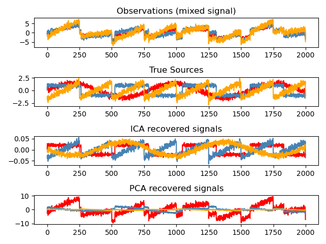

**Total running time of the script:** (0 minutes 0.386 seconds)

[figure not shown]

[`Download Jupyter notebook: plot_ica_blind_source_separation.ipynb`](https://scikit-learn.org/1.9/_downloads/3018e0d07b27e25beba9764116709763/plot_ica_blind_source_separation.ipynb)

[`Download Python source code: plot_ica_blind_source_separation.py`](https://scikit-learn.org/1.9/_downloads/b122040dba159b8887080828461a517e/plot_ica_blind_source_separation.py)

[`Download zipped: plot_ica_blind_source_separation.zip`](https://scikit-learn.org/1.9/_downloads/2cb37d76ae6c02821275d6ef8b96620f/plot_ica_blind_source_separation.zip)

#### Related examples

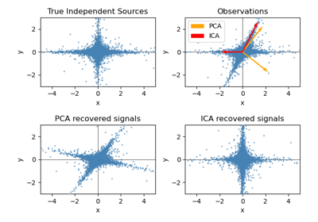

FastICA on 2D point clouds

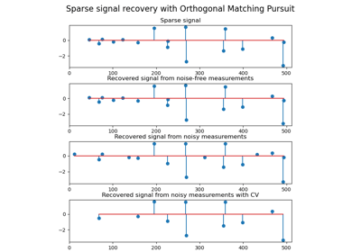

Orthogonal Matching Pursuit

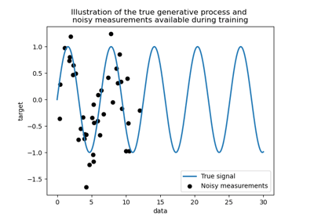

Comparison of kernel ridge and Gaussian process regression

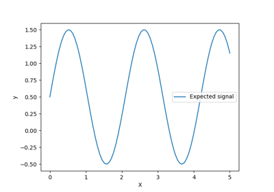

Ability of Gaussian process regression (GPR) to estimate data noise-level

© 2007–2026 The scikit-learn developers  
Licensed under the 3-clause BSD License.  
https://scikit-learn.org/1.9/auto_examples/decomposition/plot_ica_blind_source_separation.html